# P2P workshop: DADA2

Antonio Fernandez-Guerra & Pelin Yilmaz

11/10/2017

# 1 Introduction

In the following tutorial we are going to use [DADA2](https://www.nature.com/nmeth/journal/v13/n7/full/nmeth.3869.html) to analyse the OSD2014 samples from Australia. Since the last couple of years there have been advances in the analaysis of high-throughput marker-gene sequencing datathat are able *"to infer the biological sequences in the sample prior to the introduction of amplification and sequencing errors, and distinguish sequence variants differing by as little as one nucleotide*". A recent paper [Callahan et al. 2017](https://www.nature.com/articles/ismej2017119) suggests to replace the OTUs for the Amplicon Sequence Variants (a nice discussion about why ASVs can be found [here](https://github.com/benjjneb/dada2/issues/62)). So what are those ASVs (a definition from Callahan et al. 2017):

> ASVs are inferred by a de novo process in which biological sequences are discriminated from errors on the basis of, in part, the expectation that **biological sequences are more likely to be repeatedly observed than are error-containing sequences**. As a result, ASV inference cannot be performed independently on each read—the smallest unit of data from which ASVs can be inferred is a sample. However, unlike de novo ASVs, **ASVs are consistent labels because ASVs represent a biological reality that exists outside of the data being analyzed: the DNA sequence of the assayed organism**. Thus, ASVs inferred independently from different studies or different samples can be validly compared.

In the last months one has been able to read very interesting discussions about the pros and cons of using ASVs instead of the traditional OTUs. For example [here](http://fiererlab.org/2017/05/02/lumping-versus-splitting-is-it-time-for-microbial-ecologists-to-abandon-otus/), [here](http://fiererlab.org/2017/10/09/intragenomic-heterogeneity-and-its-implications-for-esvs/) or [here](http://www.academichermit.com/2017/10/11/Review-of-Updating-the-97-identity-threshold.html).

# 2 DADA2

Let's go through the tutorial on how to analyse the OSD2014 australian data. This tutorial is almost an identical copy to the one from the DADA2 developers ([**here**](https://benjjneb.github.io/dada2/tutorial.html)), all kudos for them.

> Always check the original one as will be up-to-date

Before starting we have to be sure that our files are in good shape:

> Samples have been demultiplexed, i.e. split into individual per-sample fastq files. Non-biological nucleotides have been removed, e.g. primers, adapters, linkers, etc. If paired-end sequencing data, the forward and reverse fastq files contain reads in matched order. If these criteria are not true for your data (are you sure there aren’t any primers hanging around?) you need to remedy those issues before beginning this workflow. See the FAQ for some recommendations for common issues.

## 2.1 Installing DADA2

```r
library("devtools")
devtools::install_github("benjjneb/dada2")
```

## 2.2 Asses quality of our samples

First we will define where is our data. We will use the **wednesday/data/fastq/** folder from our cloned repo:

```r
library(dada2)
library(tidyverse)
path <- "../wednesday/data/fastq/"
list.files(path)
```

```
##  [1] "filtered"                    "OSD188_6_14_RI_R1.fastq.gz"
##  [3] "OSD188_6_14_RI_R2.fastq.gz"  "OSD189_6_14_YNG_R1.fastq.gz"
##  [5] "OSD189_6_14_YNG_R2.fastq.gz" "OSD190_6_14_KI_R1.fastq.gz"
##  [7] "OSD190_6_14_KI_R2.fastq.gz"  "OSD191_6_14_DRW_R1.fastq.gz"
##  [9] "OSD191_6_14_DRW_R2.fastq.gz" "OSD31_6_14_PH_R1.fastq.gz"
## [11] "OSD31_6_14_PH_R2.fastq.gz"   "OSD32_6_14_NSI_R1.fastq.gz"
## [13] "OSD32_6_14_NSI_R2.fastq.gz"  "OSD33_6_14_MI_R1.fastq.gz"
## [15] "OSD33_6_14_MI_R2.fastq.gz"
```

Let's define a list of file names based searching for the pattern **_R1.fastq.gz** or **_R2.fastq.gz** and parse the file names from the files to be **OSD33** for example:

```r
fnFs <- sort(list.files(path, pattern="_R1.fastq.gz", full.names = TRUE))
fnRs <- sort(list.files(path, pattern="_R2.fastq.gz", full.names = TRUE))
sample.names <- sapply(strsplit(basename(fnFs), "_"), `[`, 1)
```

## 2.3 Quality profiles

Once we know where are the files, lets explore their quality profiles. For the forward:

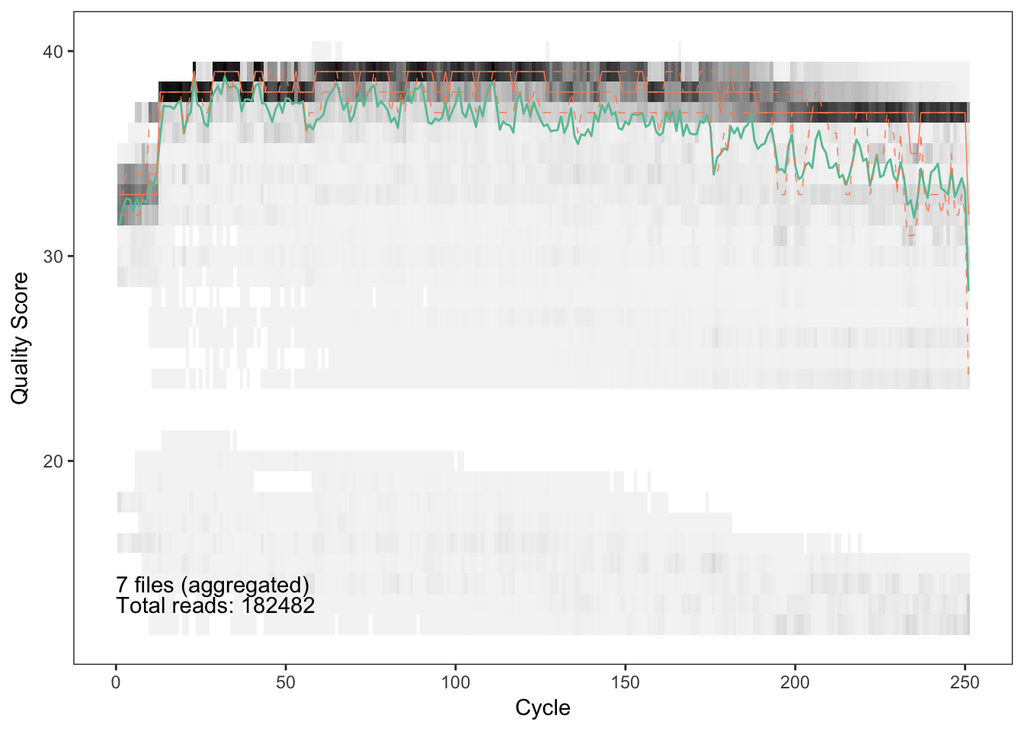

```r
plotQualityProfile(fnFs, aggregate = TRUE)
```

And for the reverse:

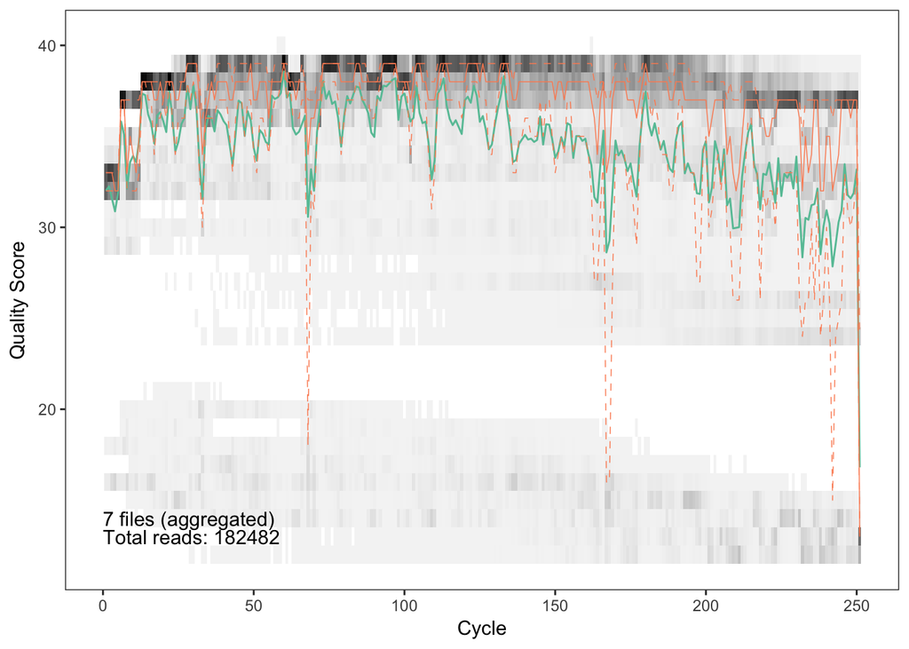

```r
plotQualityProfile(fnRs, aggregate = TRUE)
```

> **Note:** In our case, **aggrate** could be **FALSE** as we have just a few samples, but for a large number of samples can be useful to see global quality trends

This step is very important as we need to figure out which will be the best threshold to trim our reads. If we trim too much, we will not be able to overlap both pair ends, but if we don't trim enough we can have low quality regions.

## 2.4 Filter and trimming

Once we decided our quality thresholds, let's create the file names for the trimmed files:

```r
filt_path <- file.path(path, "filtered") # Place filtered files in filtered/ subdirectory
filtFs <- file.path(filt_path, paste0(sample.names, "_F_filt.fastq.gz"))
filtRs <- file.path(filt_path, paste0(sample.names, "_R_filt.fastq.gz"))
```

Now is time to filter and trim our reads:

```r
out <- filterAndTrim(fnFs, filtFs, fnRs, filtRs, truncLen = c(245,240),
              maxN = 0, maxEE = c(2,2), truncQ = 2, rm.phix = TRUE,
              compress = TRUE, multithread = 2)
```

> Our reads look like to have a very quality, here we decided to trim at positions 245 and 240, but for your data you should carefully look at the quality profiles and try different thresholds. In addition, we will discard any reads with an N (**maxN = 0**), we only will allow 2 errors in both pairs (**maxEE = c(2,2)**) and we will truncate the reads when the quality is smaller than 2 (**truncQ = 2**). For other options use **?filterAndTrim** to get extra information

Let's check how much we filtered out:

```r
head(out)
```

```
##                             reads.in reads.out
## OSD188_6_14_RI_R1.fastq.gz     27246     23663
## OSD189_6_14_YNG_R1.fastq.gz    31043     27164
## OSD190_6_14_KI_R1.fastq.gz     24703     21899
## OSD191_6_14_DRW_R1.fastq.gz    26109     22428
## OSD31_6_14_PH_R1.fastq.gz      26117     22767
## OSD32_6_14_NSI_R1.fastq.gz     28391     24779
```

## 2.5 Learn error rates

Now we are going to learn the different error rates from our reads. The DADA2 algorithm depends on a parametric error model (err) and every amplicon dataset has a different set of error rates. The learnErrors method learns the error model from the data, by alternating estimation of the error rates and inference of sample composition until they converge on a jointly consistent solution. As in many optimization problems, the algorithm must begin with an initial guess, for which the maximum possible error rates in this data are used (the error rates if only the most abundant sequence is correct and all the rest are errors). This can take a while, so be patient :-)

First for the forward:

```r
errF <- learnErrors(filtFs, multithread=2)
```

and for the reverse:

```r
errR <- learnErrors(filtRs, multithread=2)
```

Let's explore the estimated error rates. For the forward:

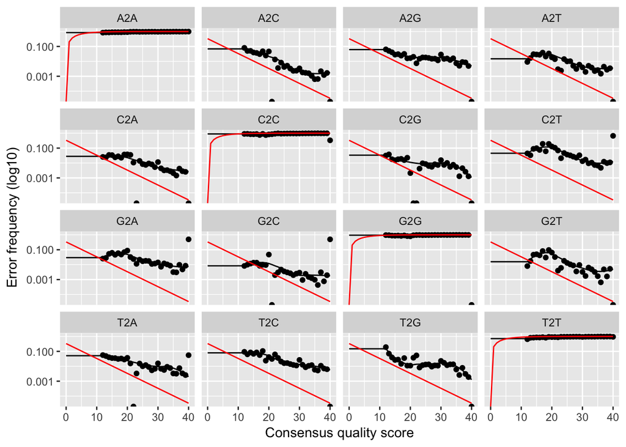

```r
plotErrors(errF, nominalQ=TRUE)
```

and for the reverse:

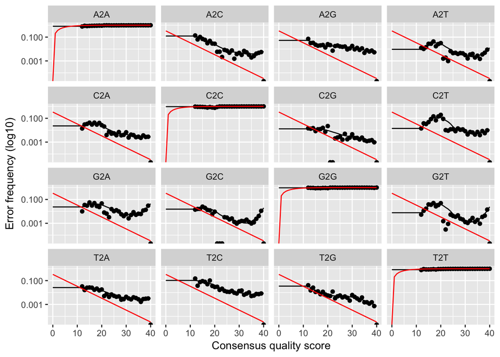

```r
plotErrors(errR, nominalQ=TRUE)
```

The error rates for each possible transition (eg. A->C, A->G, …) are shown. Points are the observed error rates for each consensus quality score. The black line shows the estimated error rates after convergence. The red line shows the error rates expected under the nominal definition of the Q-value.

## 2.6 Dereplication

Now we are going to combine all identical sequencing reads into *unique sequences* keeping track of their abundances. Dereplication is useful to reduce the computation time by eliminating redundant comparisons.

> Dereplication in the DADA2 pipeline has one crucial addition from other pipelines: DADA2 retains a summary of the quality information associated with each unique sequence. The consensus quality profile of a unique sequence is the average of the positional qualities from the dereplicated reads. These quality profiles inform the error model of the subsequent denoising step, significantly increasing DADA2’s accuracy.

Let's dereplicate:

```r
derepFs <- derepFastq(filtFs, verbose=TRUE)
derepRs <- derepFastq(filtRs, verbose=TRUE)
```

Let's name the dereplicated objects:

```r
names(derepFs) <- sample.names
names(derepRs) <- sample.names
```

## 2.7 Sample inference

Now is time to apply the DADA2 algorithm to identify the sequence variants. Check the [publication](https://www.nature.com/nmeth/journal/v13/n7/full/nmeth.3869.html) for a detailed explanation of the method.

Forward:

```r
dadaFs <- dada(derepFs, err=errF, multithread=2)
```

Reverse:

```r
dadaRs <- dada(derepRs, err=errR, multithread=2)
```

## 2.8 Merge paired reads

Merging both pair ends will help to reduce the number of spurious sequence variants. Let's merge!

```r
mergers <- mergePairs(dadaFs, derepFs, dadaRs, derepRs, verbose=TRUE)
```

Let's have a look to the results:

```r
head(mergers[[1]])
```

```
##                                                                                                                                                                                                                                                         sequence
## 1  TACGGGAGTGGCAAGCGTTATCCGGAATTATTGGGCGTAAAGCGTCCGCAGGCGGCCCTT…
## 2  TACGGAGGATCCAAGCGTTATCCGGAATTATTGGGTTTAAAGGGTCCGCAGGCTGTTTGT…
## 3 TACGTAGGGGGCGAGCGTTGTCCGGATTTATTGGGCGTAAAGAGCTCGTAGGCGGTTCAA…
## 4  TACGGATGGTGCAAGCGTTAATCGGAATTACTGGGCGTAAAGCGCGCGTAGGTGGCATAT…
## 5 TACGTAGGGGGCGAGCGTTGTCCGGATTTATTGGGCGTAAAGAGCTCGTAGGCGGTTCAA…
## 6  TACGGAGGGTGCAAGCGTTAATCGGAATTACTGGGCGTAAAGCGCACGCAGGCGGTCTGT…
##   abundance forward reverse nmatch nmismatch nindel prefer accept
## 1      1365       1       1    232         0      0      1   TRUE
## 2       726       2       2    232         0      0      1   TRUE
## 3       691       3       3    231         0      0      1   TRUE
## 4       497       4       4    232         0      0      1   TRUE
## 5       444       5       5    231         0      0      1   TRUE
## 6       426       7       6    232         0      0      1   TRUE
```

> Most of your reads should successfully merge. If that is not the case upstream parameters may need to be revisited: Did you trim away the overlap between your reads?

## 2.9 Build the sequence table

We can summarise all results from previous steps and get a higher resolution table:

```r
seqtab <- makeSequenceTable(mergers)
```

```
## The sequences being tabled vary in length.
```

```r
dim(seqtab)
```

```
## [1]    7 1039
```

```r
table(nchar(getSequences(seqtab)))
```

```
##
## 251 252 253 254 255 256 257 258 260 262 422
##   4  34 921  57   6   3   5   5   1   2   1
```

Check the sequence distribution of your sequences, if you have shorter on longer than what you expect you should remove them. For example you can use if we are expecting a fragment of 250, we can do `seqtab2 <- seqtab[,nchar(colnames(seqtab)) %in% seq(250,256)])`

## 2.10 Remove chimeras

Even though DADA2 removed susbtitution and indel errors, chimeras can be still present. The good thing is that removing chimeras from ASVs is easier than with the OTUs: all sequences which can be exactly reconstructed as a bimera (two-parent chimera) from more abundant sequences.

```r
seqtab.nochim <- removeBimeraDenovo(seqtab, method="consensus", multithread=2, verbose=TRUE)
dim(seqtab.nochim)
```

[output not shown]

How many reads we lose due to chimeras:

```r
sum(seqtab.nochim)/sum(seqtab)
```

```
## [1] 0.9777949
```

## 2.11 Track reads through the pipeline

Now we can summarise the different steps of the pipeline:

```r
getN <- function(x) sum(getUniques(x))
track <- cbind(out, sapply(dadaFs, getN), sapply(mergers, getN), rowSums(seqtab), rowSums(seqtab.nochim))
# If processing a single sample, remove the sapply calls: e.g. replace sapply(dadaFs, getN) with getN(dadaFs)
colnames(track) <- c("input", "filtered", "denoised", "merged", "tabled", "nonchim")
rownames(track) <- sample.names
head(track)
```

```
##        input filtered denoised merged tabled nonchim
## OSD188 27246    23663    23663  21958  21958   21760
## OSD189 31043    27164    27164  25994  25994   25104
## OSD190 24703    21899    21899  20384  20384   20184
## OSD191 26109    22428    22428  20402  20402   19868
## OSD31  26117    22767    22767  21091  21091   20451
## OSD32  28391    24779    24779  22703  22703   22130
```

Let's plot the results:

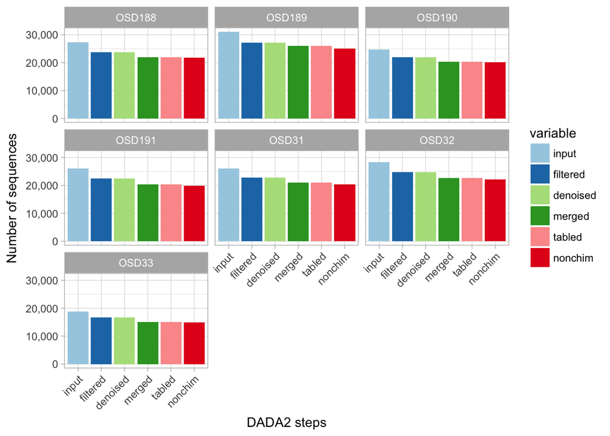

```r
track_long <- as.data.frame(track) %>%
  rownames_to_column(var = "sample") %>%
  gather(variable, value, -sample) %>%
  tbl_df()

track_long$variable <- factor(track_long$variable, levels = colnames(track))

ggplot(track_long, aes(variable, value, fill = variable)) +
  geom_bar(stat = "identity", position = "dodge") +
  scale_fill_brewer(palette="Paired") +
  facet_wrap(~sample) +
  xlab("DADA2 steps") +
  ylab("Number of sequences") +
  theme_light() +
  theme(axis.text.x = element_text(angle = 45, hjust = 1)) +
  scale_y_continuous(labels = scales::comma)
```

## 2.12 Assign taxonomy

DADA2 uses the [RDP's naive Bayesian classifier](http://www.ncbi.nlm.nih.gov/pubmed/17586664) to taxonomically classify the sequence variants. We are going to use the SILVA database as a reference:

```r
taxa <- assignTaxonomy(seqtab.nochim, "../wednesday/data/resources/Training/silva_nr_v128_train_set.fa.gz", multithread = 2)
```

Let's have a look to the taxonomic assignments:

```r
taxa.print <- taxa # Removing sequence rownames for display only
rownames(taxa.print) <- NULL
head(taxa.print)
```

```
##      Kingdom    Phylum           Class                 Order
## [1,] "Bacteria" "Cyanobacteria"  "Cyanobacteria"       "SubsectionI"
## [2,] "Bacteria" "Bacteroidetes"  "Flavobacteriia"      "Flavobacteriales"
## [3,] "Bacteria" "Actinobacteria" "Acidimicrobiia"      "Acidimicrobiales"
## [4,] "Bacteria" "Actinobacteria" "Acidimicrobiia"      "Acidimicrobiales"
## [5,] "Bacteria" "Proteobacteria" "Alphaproteobacteria" "Rhodobacterales"
## [6,] "Bacteria" "Proteobacteria" "Gammaproteobacteria" "Oceanospirillales"
##      Family              Genus                     Species
## [1,] "FamilyI"           "Synechococcus"           NA
## [2,] "Flavobacteriaceae" "NS5_marine_group"        NA
## [3,] "OM1_clade"         "Candidatus_Actinomarina" NA
## [4,] "OM1_clade"         "Candidatus_Actinomarina" NA
## [5,] "Rhodobacteraceae"  NA                        NA
## [6,] "SAR86_clade"       NA                        NA
```

Finally we have our ASVs ready for downstream analyses :-)

# 3 Phyloseq

- **otu_table**: for constructing and accessing ASV abundance objects
- **sample_data**: for constructing and accessing a table of sample-level variables
- **tax_table**: for constructing and accessing a table of taxonomic names, organized with ranks as columns

Let's read the contextual data:

```r
sam_df <- read_tsv(file = "data/for_R/ms174_p2p-workshop_ref_sample_data.tsv", col_names = TRUE) %>%
  as.data.frame()
row.names(sam_df) <- sam_df$label
```

And finally we combine everything in a phyloseq object

```r
library(phyloseq)

ms174_physeq <- phyloseq(otu_table(seqtab.nochim, taxa_are_rows=FALSE),
               sample_data(sam_df),
               tax_table(taxa))
ms174_physeq
```

```
## phyloseq-class experiment-level object
## otu_table()   OTU Table:         [ 993 taxa and 7 samples ]
## sample_data() Sample Data:       [ 7 samples by 17 sample variables ]
## tax_table()   Taxonomy Table:    [ 993 taxa by 7 taxonomic ranks ]
```

Phyloseq provides many methods to access our data. For example let's get the names of the samples:

```r
sample_names(ms174_physeq)
```

```
## [1] "OSD188" "OSD189" "OSD190" "OSD191" "OSD31"  "OSD32"  "OSD33"
```

Or the sample variable names:

```r
sample_variables(ms174_physeq)
```

```
##  [1] "label"            "osd_id"           "local_date"
##  [4] "water_depth"      "protocol"         "start_lat"
##  [7] "start_lon"        "stop_lat"         "stop_lon"
## [10] "mean_lat"         "mean_long"        "noaa_temperature"
## [13] "noaa_salinity"    "noaa_nitrate"     "noaa_phosphate"
## [16] "noaa_silicate"    "noaa_oxygen"
```

Or the ASV names:

```r
taxa_names(ms174_physeq)[1:10]
```

```
##  [1] "TACGGGAGTGGCAAGCGTTATCCGGAATTATTGGGCGTAAAGCGTCCGCAGGCGGCCCTT…"
##  [2] "TACGGAGGATCCAAGCGTTATCCGGAATTATTGGGTTTAAAGGGTCCGCAGGCTGTTTGT…"
##  [3] "TACGTAGGGGGCGAGCGTTGTCCGGATTTATTGGGCGTAAAGAGCTCGTAGGCGGTTCAA…"
##  [4] "TACGTAGGGGGCGAGCGTTGTCCGGATTTATTGGGCGTAAAGAGCTCGTAGGCGGTTCAA…"
##  [5] "TACGGAGGGGGTTAGCGTTGTTCGGAATTACTGGGCGTAAAGCGCACGTAGGCGGATTAG…"
##  [6] "TACGGATGGTGCAAGCGTTAATCGGAATTACTGGGCGTAAAGCGCGCGTAGGTGGCATAT…"
##  [7] "TACGGAGGGTCCAAGCGTTAATCGGAATTACTGGGCGTAAAGCGCGCGTAGGCGGTTTAG…"
##  [8] "TACGGAGGGTGCAAGCGTTAATCGGAATTACTGGGCGTAAAGCGCACGCAGGCGGTCTGT…"
##  [9] "TACGGGAGTGGCAAGCGTTATCCGGAATTATTGGGCGTAAAGCGTCCGCAGGCGGCTTTT…"
## [10] "TACGGGGGATGCAAGCGTTATCCGGAATCATTGGGCGTAAAGCGCCTGTAGGTTGTTTAA…"
```

We can subset data, for example let's keep only the ASVs from Bacteroidetes:

```r
ms174_physeq_bct = subset_taxa(ms174_physeq, Phylum == "Bacteroidetes")
ms174_physeq_bct
```

```
## phyloseq-class experiment-level object
## otu_table()   OTU Table:         [ 151 taxa and 7 samples ]
## sample_data() Sample Data:       [ 7 samples by 17 sample variables ]
## tax_table()   Taxonomy Table:    [ 151 taxa by 7 taxonomic ranks ]
```

We can see that 151 ASVs belong to the phylum Bacteroidetes.

Phyloseq also provides really nice graphical capabilities based on ggplot2. For example with **plot_bar** we can plot the abundance of Bacteroidetes in each sample:

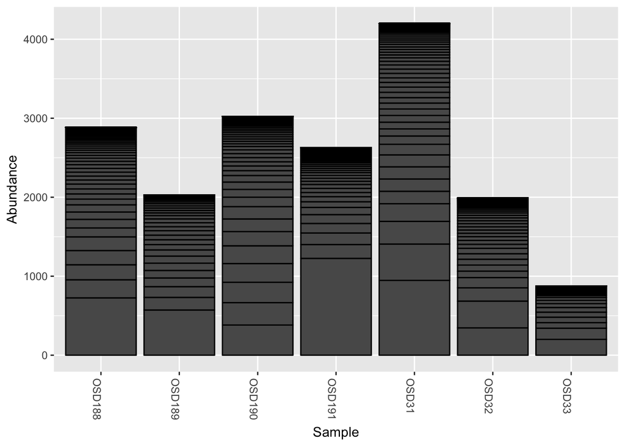

```r
plot_bar(ms174_physeq_bct)
```

And color the plot based in the order:

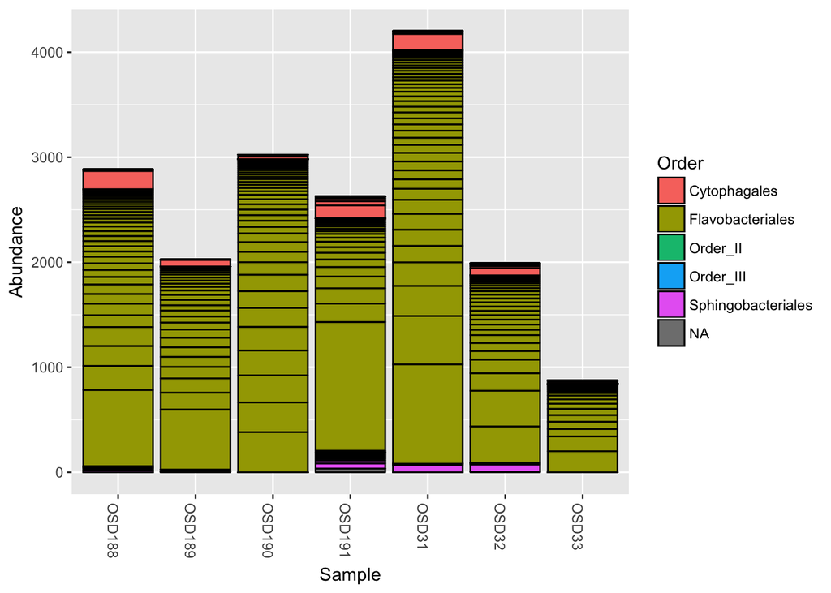

```r
plot_bar(ms174_physeq_bct, fill="Order")
```

We can see that Flavobacteriales are the most abundant.

Let's collect the Chloroplasts and Mitochondria ASVs and store in an object:

> It is always interesting to keep track of them and maybe will be useful to answer some questions

```r
ms174_physeq_chl_mit <- subset_taxa(ms174_physeq, (Class == "Chloroplast" | Family == "Mitochondria"))
```

Now let's remove them from the *ms174_physeq* object:

```r
chl_mit_tax <- taxa_names(ms174_physeq_chl_mit)
all_tax <- taxa_names(ms174_physeq)
keep_taxa <- all_tax[!(all_tax %in% chl_mit_tax)]
ms174_physeq <- prune_taxa(keep_taxa, ms174_physeq)
ms174_physeq
```

```
## phyloseq-class experiment-level object
## otu_table()   OTU Table:         [ 878 taxa and 7 samples ]
## sample_data() Sample Data:       [ 7 samples by 17 sample variables ]
## tax_table()   Taxonomy Table:    [ 878 taxa by 7 taxonomic ranks ]
```

Phyloseq also has methods to rarefy to even depth and estimate and calculate measures of alpha diversity:

```r
ms174_physeq_rar <- rarefy_even_depth(ms174_physeq)
```

```
## You set `rngseed` to FALSE. Make sure you've set & recorded
##  the random seed of your session for reproducibility.
## See `?set.seed`
```

```
## ...
```

```
## 5OTUs were removed because they are no longer
## present in any sample after random subsampling
```

```
## ...
```

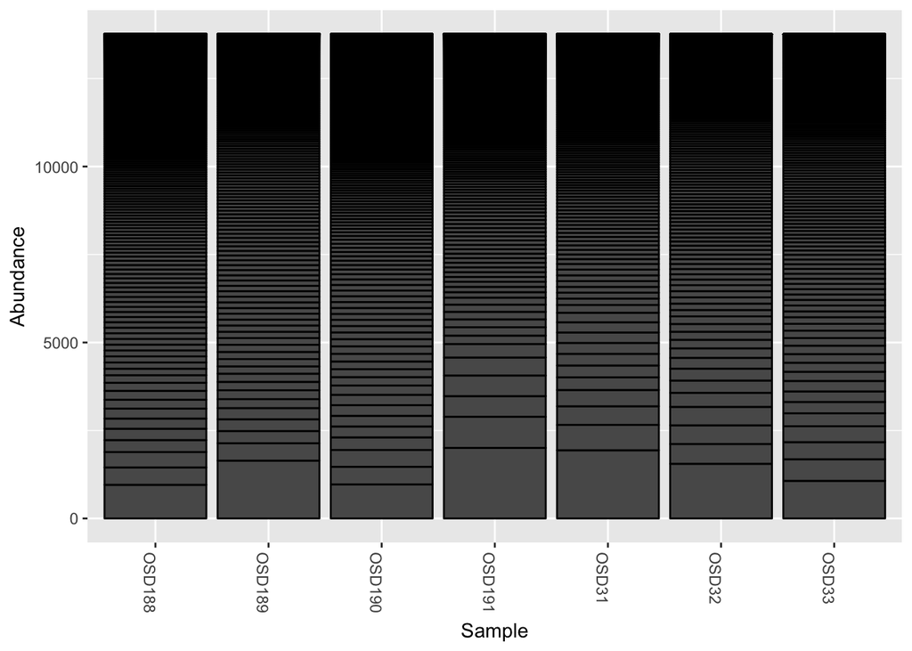

```r
plot_bar(ms174_physeq_rar)
```

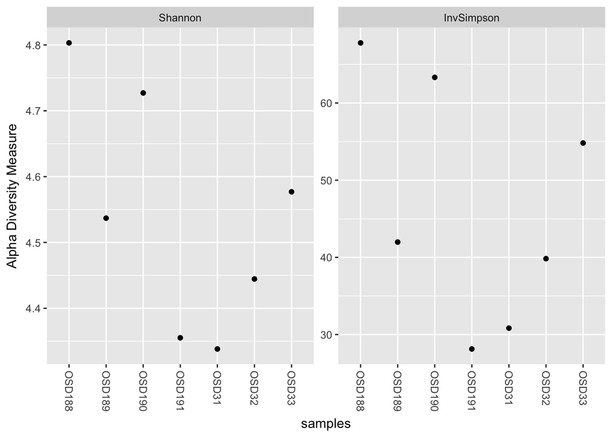

```r
plot_richness(ms174_physeq_rar, measures=c("Shannon", "InvSimpson"))
```

> **NOTE**: Be aware that ASVs can not be used to estimate **richness** with the actual methods. A nice explanation can be found [here](https://github.com/benjjneb/dada2/issues/317#issuecomment-324173595) Have in mind that the results of DADA2 (and similar methods) don't contain sigletons.

And we even can perform ordinations. For example MDS with Euclidean distance and colored by temperature:

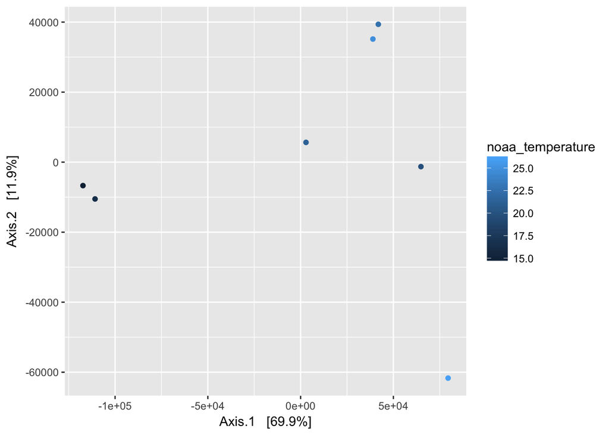

```r
ms174_physeq_even <- transform_sample_counts(ms174_physeq, function(x) 1E6 * x/sum(x))
ms174_physeq_sum <- tapply(taxa_sums(ms174_physeq_even), tax_table(ms174_physeq_even)[, "Phylum"], sum, na.rm=TRUE)
top5phyla <- names(sort(ms174_physeq_sum, TRUE))[1:5]
ms174_physeq_even <- prune_taxa((tax_table(ms174_physeq_even)[, "Phylum"] %in% top5phyla), ms174_physeq_even)

ms174_physeq_ord <- ordinate(ms174_physeq_even, "MDS", "euclidean")
plot_ordination(ms174_physeq_even, ms174_physeq_ord, type="samples", color = "noaa_temperature")
```

<sup>**Note**: All the results shown here are just for demonstration and shouldn't be applied in real life analyses. For proper analytical workflow please visit the phyloseq [website](https://joey711.github.io/phyloseq/index.html)</sup>

# 4 Exploring the data

Now we will use all what we learnt to explore our data set. First we will create a summary file where we will group the ASVs by sample, we will calculate the relative abundance of each ASV and we will remove those ASVs with 0 counts.

```r
ms174_summary <- otu_table(ms174_physeq) %>%
  as.data.frame() %>%
  rownames_to_column(var = "label") %>%
  gather(asv_name, count, -label) %>%
  group_by(label) %>%
  mutate(rel_abun = count/sum(count)) %>%
  arrange(asv_name, label) %>%
  filter(count > 0) %>%
  ungroup()
```

Let's check the number of counts per sample:

```r
ms174_readsXsample <- ms174_summary %>%
  group_by(label) %>%
  summarise(counts = sum(count))
summary(ms174_readsXsample$counts)
```

```
##    Min. 1st Qu.  Median    Mean 3rd Qu.    Max.
##   13763   17600   18789   18702   19668   23824
```

We we will explore the amount of **absolute singletons** and **abundant singletons** where, **absolute singletons** are those sequences which are only **one time present** in **one sample**, while the **abundant singletons** are those singletons (occurring only one time per sample) that have been observed in more samples and are quite abundant. The absolute singletons most probably are sequencing errors, although in our example is difficult to say due the low number of samples.

```r
ms174_prevalence <- ms174_summary %>%
  select(asv_name, count) %>%
  group_by(asv_name) %>%
  summarise(prev = sum(count >0), total_counts = sum(count))

ms174_abs_singletons <- ms174_prevalence %>%
  dplyr::filter(total_counts <= 1, prev <= 1)

ms174_abun_singletons <- ms174_prevalence %>%
  dplyr::filter(total_counts > 1, prev <= 1)

ms174_abs_singletons_names <- ms174_abs_singletons$asv_name

# Remove absolute singletons
ms174_prevalence <- ms174_prevalence %>%
  filter(!(asv_name %in% ms174_abs_singletons_names))
```

```r
ms174_counts <- data.frame(class = c("Total ASVs","Absolute singletons", "Abundant singletons"),
                           counts = c(length(unique(ms174_summary$asv_name)),
                                      dim(ms174_abs_singletons)[1],
                                      dim(ms174_abun_singletons)[1]))

print(ms174_counts)
```

```
##                 class counts
## 1          Total ASVs    878
## 2 Absolute singletons      0
## 3 Abundant singletons    566
```

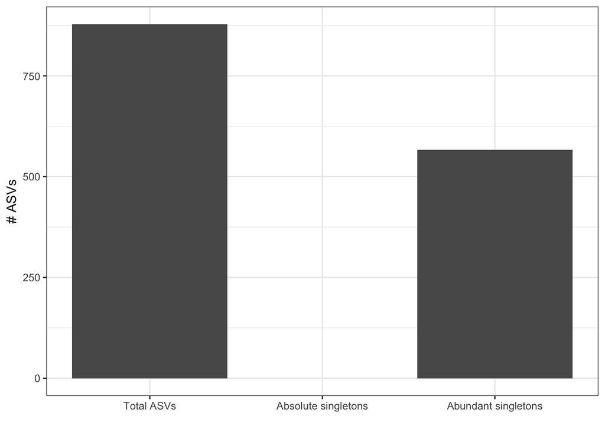

```r
ms174_counts$class <- factor(ms174_counts$class, levels=c("Total ASVs","Absolute singletons", "Abundant singletons"))

ggplot(ms174_counts, aes(class, counts)) +
  geom_bar(stat = "identity") + theme_bw() +
  xlab("") + ylab("# ASVs")
```

As we can see, there are no **absolute singletons**, in case you observe some of them, they are coming from the merging steps.

## 4.1 ASV prevalence

Next step is to analyse the prevalence of the remaining ASVs. The idea is to explore the ASVs that at least appear in a certain number of samples. In a real life analysis this should be careful examined. The following plots will help to choose the best threshold:

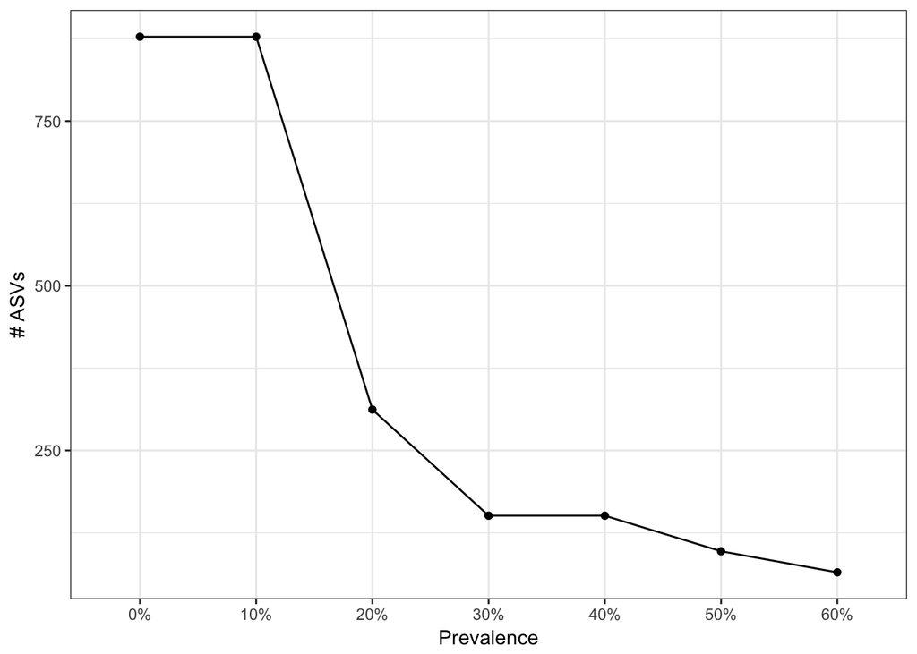

```r
ms174_prevalence_dist <- lapply(seq(0.00,0.60,0.1), function (X) {
  ms174_prevalence %>%
    filter(prev >= nsamples(ms174_physeq) * X) %>%
    summarise(N=n()) %>% mutate(N = N, prev=paste(100*X, "%", sep = ""), nsamples = round(nsamples(ms174_physeq) * X))
}) %>% bind_rows()

ms174_prevalence_dist$prev <- factor(ms174_prevalence_dist$prev , levels=paste(100*seq(0.00,0.60,0.1), "%", sep = ""))

ggplot(ms174_prevalence_dist, aes(prev, N, group=1)) +
  geom_line() +
  geom_point() +
  theme_bw() +
  xlab("Prevalence") + ylab("# ASVs")
```

In the plot we can see how the number of ASVs decreases as they occur in more samples.

In addition we will explore the occurrence of the different ASVs at different abundances and how many sequences we keep with each threshold. The idea is to keep ASVs with a certain abundance among the samples. In this tutorial, we only will keep those OTUs with at least 25 counts total over all samples and remove all samples with less than 10,000 counts.

```r
library(ggpubr)
```

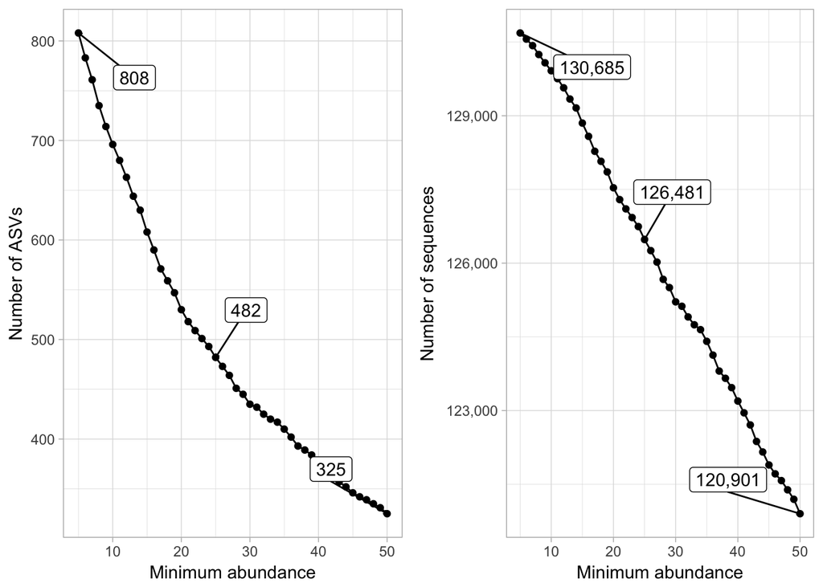

```r
library(ggrepel)

prev_results <- vector(mode = "list")
for (i in 5:50){

minabun <- i

ms174_prevalence_filt <- ms174_prevalence %>%
  filter(total_counts >= minabun)

ms174_physeq_prev <- prune_taxa(ms174_prevalence_filt %>% .$asv_name %>% as.vector, ms174_physeq)

ms174_physeq_prev <- prune_samples(sample_sums(ms174_physeq_prev) >= 10000, ms174_physeq_prev)

ms174_physeq_prev <- prune_taxa(taxa_sums(ms174_physeq_prev) > 0, ms174_physeq_prev)

prev_results[[i]] <- data.frame(minabun=i, num_seq = ms174_physeq_prev %>% sample_sums %>% sum, num_otu = ntaxa(ms174_physeq_prev))
}

prev_results <- bind_rows(prev_results)

p1 <- ggplot(prev_results, aes(minabun, num_otu)) +
  geom_line() +
  geom_point() +
  scale_y_continuous(labels = scales::comma) +
  geom_label_repel(data = prev_results %>% filter(minabun == 5), aes(minabun, num_otu, label = scales::comma(num_otu)), arrow = arrow(length = unit(0.01, 'npc')), box.padding = unit(1.5, 'lines')) +
  geom_label_repel(data = prev_results %>% filter(minabun == 25), aes(minabun, num_otu, label = scales::comma(num_otu)), arrow = arrow(length = unit(0.01, 'npc')), box.padding = unit(1.5, 'lines')) +
  geom_label_repel(data = prev_results %>% filter(minabun == 50), aes(minabun, num_otu, label = scales::comma(num_otu)), arrow = arrow(length = unit(0.01, 'npc')), box.padding = unit(1.5, 'lines')) +
  theme_light() +
  xlab("Minimum abundance") +
  ylab("Number of ASVs")



p2 <- ggplot(prev_results, aes(minabun, num_seq)) +
  geom_line() +
  geom_point() +
  scale_y_continuous(labels = scales::comma) +
  geom_label_repel(data = prev_results %>% filter(minabun == 5), aes(minabun, num_seq, label = scales::comma(num_seq)), arrow = arrow(length = unit(0.01, 'npc')), box.padding = unit(1.5, 'lines')) +
  geom_label_repel(data = prev_results %>% filter(minabun == 25), aes(minabun, num_seq, label = scales::comma(num_seq)), arrow = arrow(length = unit(0.01, 'npc')), box.padding = unit(1.5, 'lines')) +
  geom_label_repel(data = prev_results %>% filter(minabun == 50), aes(minabun, num_seq, label = scales::comma(num_seq)), arrow = arrow(length = unit(0.01, 'npc')), box.padding = unit(1.5, 'lines')) +
  theme_light() +
  xlab("Minimum abundance") +
  ylab("Number of sequences")

ggarrange(p1, p2, nrow = 1, ncol = 2)
```

Let's filter...

```r
minabun <- 25

ms174_prevalence_filt <- ms174_prevalence %>%
  filter(total_counts >= minabun)

summary(ms174_prevalence_filt$prev)
```

```
##    Min. 1st Qu.  Median    Mean 3rd Qu.    Max.
##   1.000   1.000   2.000   2.315   3.000   7.000
```

```r
ms174_physeq_filt_prev <- prune_taxa(ms174_prevalence_filt %>% .$asv_name %>% as.vector, ms174_physeq)
ms174_physeq_filt_prev
```

```
## phyloseq-class experiment-level object
## otu_table()   OTU Table:         [ 482 taxa and 7 samples ]
## sample_data() Sample Data:       [ 7 samples by 17 sample variables ]
## tax_table()   Taxonomy Table:    [ 482 taxa by 7 taxonomic ranks ]
```

We kept ~482 ASVs from the original ~878 ASVs.

We explore the counts for each sample after the filtering:

```r
ms174_readsXsample <- sample_sums(ms174_physeq_filt_prev)
summary(ms174_readsXsample )
```

```
##    Min. 1st Qu.  Median    Mean 3rd Qu.    Max.
##   13122   17017   17699   18069   19140   23346
```

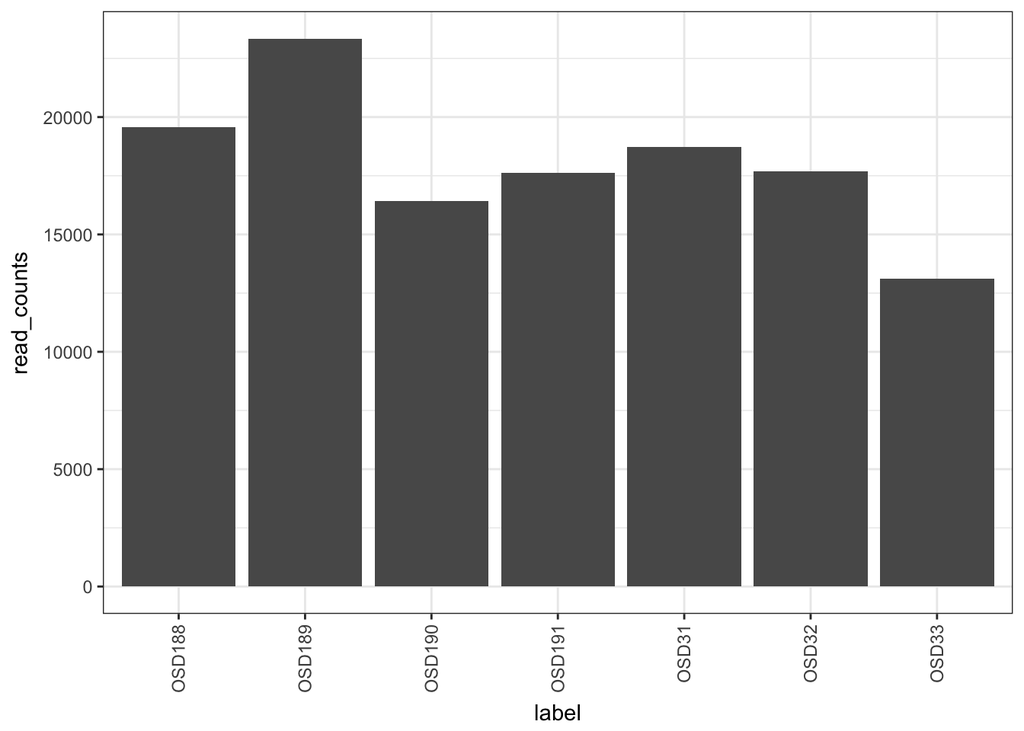

```r
ggplot(as.data.frame(ms174_readsXsample) %>% mutate(read_counts = ms174_readsXsample, label = row.names(.)), aes(label, read_counts)) +
  geom_bar(stat = "identity") +
  theme_bw() +
  theme(axis.text.x = element_text(angle = 90, vjust = 0.5, hjust = 1))
```

## 4.2 Normalization

From [McMurdie et al. 2014](http://journals.plos.org/ploscompbiol/article?id=10.1371/journal.pcbi.1003531):

> many microbiome samples are sequenced at the same time on the same DNA sequencing machine, but often result in total numbers of sequences per sample that are vastly different. The common procedure for addressing this difference in sequencing effort across samples – different library sizes – is to either (1) base analyses on the proportional abundance of each species in a library, or (2) rarefy, throw away sequences from the larger libraries so that all have the same, smallest size. We show that both of these normalization methods can work when comparing obviously-different whole microbiomes, but that neither method works well when comparing the relative proportions of each bacterial species across microbiome samples.

Here we will rarefy our data set to a common sequencing depth and the [Cumulative Sum Scaling (CSS)](http://www.nature.com/nmeth/journal/v10/n12/full/nmeth.2658.html) as implemented on the [metagenomeSeq](https://bioconductor.org/packages/release/bioc/html/metagenomeSeq.html) package

First we will rarefy our table using the *phyloseq* function **rarefy_even_depth()** and we also will calculate the proportional abundances using the *phyloseq* function **transform_sample_counts**:

```r
ms174_physeq_rar <- rarefy_even_depth(ms174_physeq_filt_prev)
```

```
## You set `rngseed` to FALSE. Make sure you've set & recorded
##  the random seed of your session for reproducibility.
## See `?set.seed`
```

```
## ...
```

```r
ms174_physeq_rar_prop <- transform_sample_counts(ms174_physeq_rar, function(x) x/sum(x))

ms174_filt_prev_prop <- transform_sample_counts(ms174_physeq_filt_prev, function(x) x/sum(x))
```

Now we will learn how to transform our data using the CSS transformation. First we will install the package from Bioconductor:

```r
source("https://bioconductor.org/biocLite.R")
biocLite("metagenomeSeq")
```

And we load the library:

```r
library(metagenomeSeq)
```

To perform the transformation we need to create our own function:

<sup>**Note**: Rows correspond to ASVs and columns to samples.</sup>

```r
cssTrans<-function(f.physeq.p = f.physeq.p, norm = norm, log = log){
  if (taxa_are_rows(f.physeq.p)){
    ASV <- as((otu_table(f.physeq.p)), "matrix")
  }else{
    ASV <- as(t(otu_table(f.physeq.p)), "matrix")
  }
  MGS <- newMRexperiment(
    counts = (ASV)
  )
  MGS <- cumNorm(MGS, p = cumNormStat(MGS))
  f.norm.p <- f.physeq.p
  otu_table(f.norm.p) <- otu_table((as.matrix(MRcounts(
    MGS,
    norm = norm,
    log = log,
    sl = median(unlist(normFactors(MGS)))
  ))), taxa_are_rows = T)
  return(f.norm.p)
}

ms174_physeq_css <- ms174_physeq_filt_prev
ms174_physeq_css <- cssTrans(ms174_physeq_filt_prev, norm = T, log = F)
```

```
## Default value being used.
```

```r
ms174_physeq_css_prop <- transform_sample_counts(ms174_physeq_css, function(x) x/sum(x))
ms174_physeq_css <- cssTrans(ms174_physeq_filt_prev, norm = T, log = T)
```

```
## Default value being used.
```

## 4.3 Occurrence

In this section we will explore the occurrence of the ASVs and we will identify which ones are endemic or ubiquitous

```r
ntaxa(ms174_physeq_filt_prev)
```

```
## [1] 482
```

```r
abd <- otu_table(ms174_physeq_filt_prev) %>%
  as.data.frame() %>%
  rownames_to_column(var = "label") %>%
  gather(asv_id, count, -label) %>%
  filter(count > 0)

abd_site <- abd %>%
  group_by(asv_id, label) %>%
  dplyr::summarise(count = sum(count))

abd_numb <- abd_site %>%
  dplyr::select(asv_id) %>%
  group_by(asv_id) %>%
  dplyr::count()

abd_abund <- abd_site %>%
  dplyr::select(asv_id, count) %>%
  group_by(asv_id) %>%
  dplyr::summarise(mean_abun = mean(count))

abundxsample <- abd_numb %>%
  left_join(abd_abund)
abundxsample <- abd_numb %>%
  left_join(abd_abund) %>%
  dplyr::mutate(distr = ifelse( n < 3 & mean_abun >= 100, "endemic",
                                ifelse( n > 6 & mean_abun >= 100, "ubiquitous" ,"NA")))
```

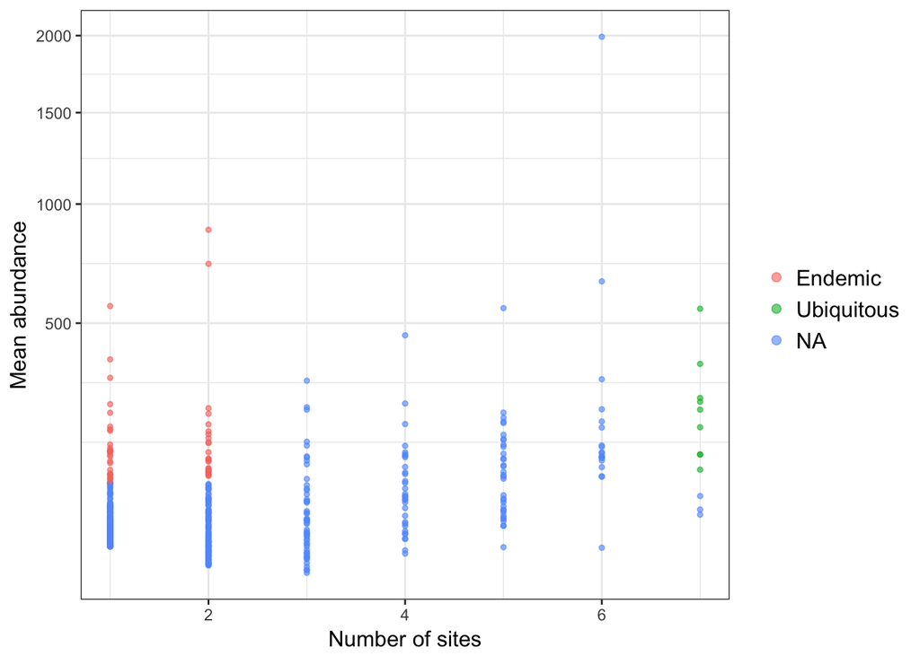

```r
abundxsample$distr <- factor(abundxsample$distr, levels=c("endemic", "ubiquitous", "NA"),
                             labels=c("Endemic", "Ubiquitous", "NA"))

ggplot(abundxsample,  aes(n, mean_abun, color = distr)) +
  geom_point(size=1, alpha = 0.6) + theme_bw() +
  scale_y_sqrt() +
  xlab("Number of sites") +
  ylab("Mean abundance") +
  guides(colour = guide_legend(override.aes = list(size=2))) +
  theme(plot.title = element_text(size = 14, face = "bold"),
        legend.position="right",
        legend.title=element_blank(),
        legend.key=element_blank(),
        legend.background = element_rect(fill=alpha('white', 0.4)),
        axis.title=element_text(size=12),
        legend.text=element_text(size=12),
        legend.text.align=0)
```

```r
ms174_physeq_df <- as.data.frame(otu_table(ms174_physeq_filt_prev))
```

> Remember this is a dummy example

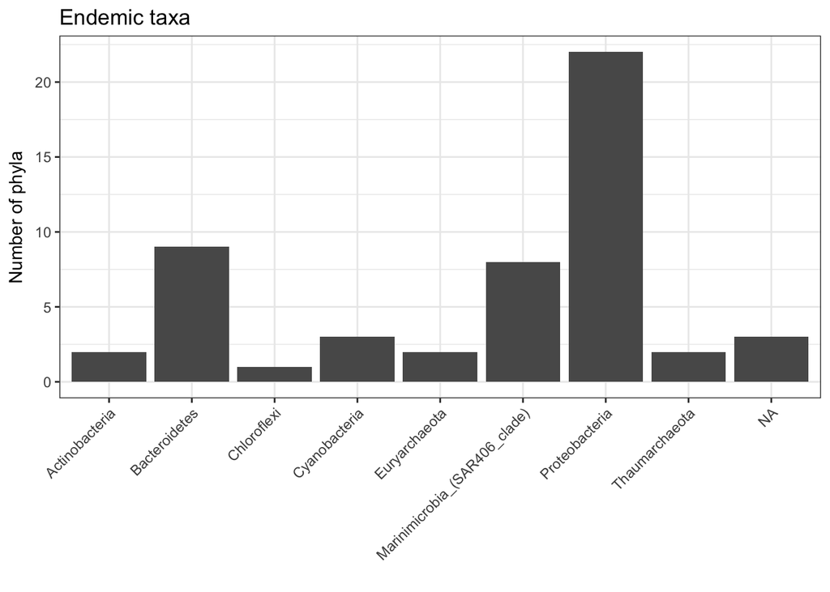

```r
empty_as_na <- function(x){
  if("factor" %in% class(x)) x <- as.character(x) ## since ifelse wont work with factors
  ifelse(as.character(x)!="", x, NA)
}

tax_table(ms174_physeq_filt_prev)[abundxsample %>%
                       filter(distr ==  "Endemic") %>%
                       .$asv_id,] %>%
  as.data.frame() %>%
  select(Phylum) %>%
  ggplot(aes(Phylum)) +
  geom_bar() +
  theme_bw() +
  theme(axis.text.x = element_text(angle = 45, hjust = 1, vjust = 1)) +
  xlab("") +
  ylab("Number of phyla") +
  ggtitle("Endemic taxa")
```

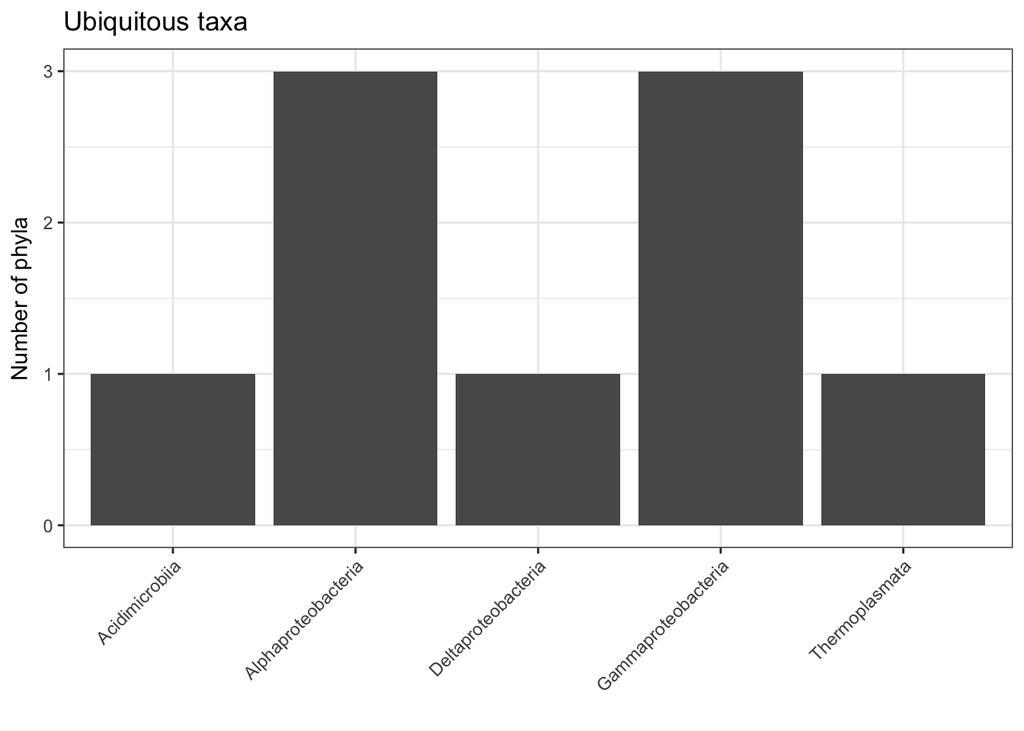

```r
tax_table(ms174_physeq_filt_prev)[abundxsample %>%
                       filter(distr ==  "Ubiquitous") %>%
                       .$asv_id,] %>%
  as.data.frame() %>%
  select(Class) %>%
  ggplot(aes(Class)) +
  geom_bar() +
  theme_bw() +
  theme(axis.text.x = element_text(angle = 45, hjust = 1, vjust = 1)) +
  xlab("") +
  ylab("Number of phyla") +
  ggtitle("Ubiquitous taxa")
```

## 4.4 Alpha diversity

Knowing how many different types of organims are present in a sample (diversity) and how they are distributed (eveness) is one of the questions that microbial ecologists want to resolve. There are many different approaches to calculate the diversity indices. In this example we will use [**breakaway**](https://github.com/adw96/breakaway) from Amy Willis (have a look to her lectures [here](https://stamps.mbl.edu/index.php/Schedule))

We will follow the tutorial on **Estimating alpha diversity** in the **Getting started** document.

First we will create a frequency table from our ASV table:

```r
library(breakaway)
ms174_asv_table <- t(otu_table(ms174_physeq))
ms174_ftable <- build_frequency_count_tables(ms174_asv_table)
```

The table shows the frequency of how many times we observed an ASV.

```r
head(ms174_ftable[[1]])
```

```
##      Index Frequency
## [1,]     2         9
## [2,]     3         4
## [3,]     4         4
## [4,]     5         6
## [5,]     6         5
## [6,]     7         9
```

Let's get a estimate of **Shannon** diversity for the first sample:

```r
shannon(ms174_ftable[[1]])
```

```
## [1] 4.815435
```

It's important to know how variable are our estimates, let's use the function **resample_estimate** to get a feeling about the variability:

```r
set.seed(2) # the following functions are random, so let's set the seed (allows reproducibility)
resample_estimate(ms174_asv_table[,1], shannon)
```

```
## [1] 4.785957
```

```r
resample_estimate(ms174_asv_table[,1], shannon)
```

```
## [1] 4.795215
```

```r
resample_estimate(ms174_asv_table[,1], shannon)
```

```
## [1] 4.820698
```

In our dummy example the variation is not to high, but we see how our estimates slightly change. Let's repeat what we have done many times:

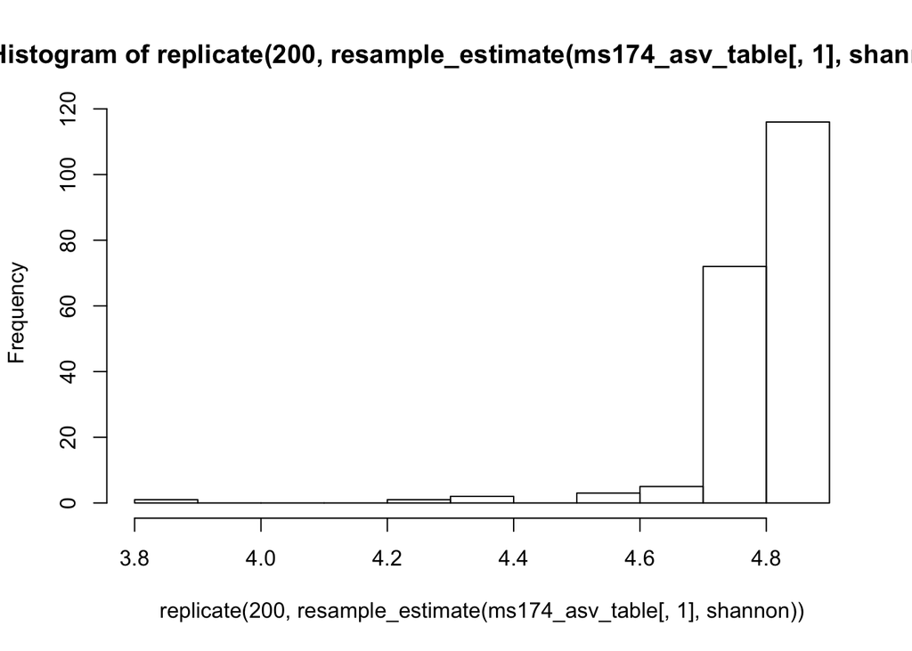

```r
par(mfrow=c(1,1))
hist(replicate(200, resample_estimate(ms174_asv_table[,1], shannon)))
```

Now we can see that there is some negative skew, suggesting that might be the risk of observing some low shannon estimates. We don't know how is causing this variability, but one source of it can be differences in the ammount of reads in each sample. Let's explore how many reads do we have in each sample:

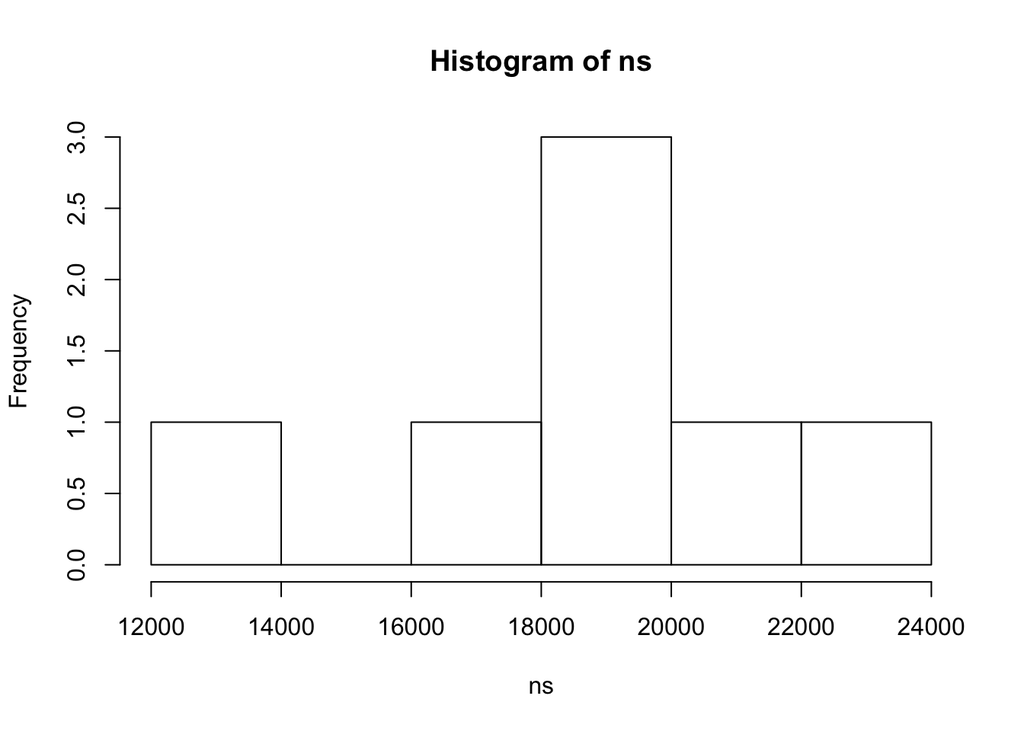

```r
ns <- unlist(lapply(ms174_ftable, function(x) sum(x[,1]*x[,2])))
hist(ns)
```

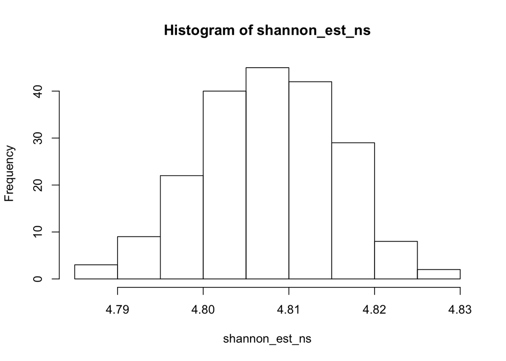

```r
set.seed(8)
shannon_est_ns <- replicate(200, resample_estimate(ms174_asv_table[,1], shannon, my_sample_size = ns))
hist(shannon_est_ns)
```

In our case the variability is quite low, but we just have a dummy example

```r
sd(shannon_est_ns)
```

```
## [1] 0.008075191
```

## 4.5 Modeling alpha diversity

Now let's do some comparisons between samples:

```r
estimates_shannon <- matrix(NA,nrow=dim(ms174_asv_table)[2],ncol=4)
rownames(estimates_shannon) <- colnames(ms174_asv_table)
colnames(estimates_shannon) <- c("shannon_est","shannon_seest","shannon_lcb","shannon_ucb")
for (i in 1:dim(ms174_asv_table)[2]) {
  samples <- replicate(200, resample_estimate(ms174_asv_table[,i], shannon, my_sample_size = ns))
  estimates_shannon[i,1] <- mean(samples)
  estimates_shannon[i,2] <- sd(samples)
  estimates_shannon[i,3:4] <- quantile(samples, c(0.025, 0.975))
}
```

Here gives us our estimates and standard errors so we can have a look estimates_shannon[,1:]. The function **betta_pic** will plot the results.

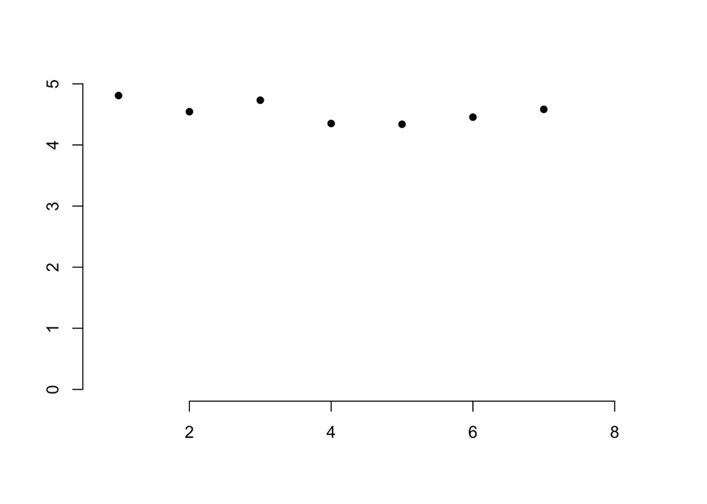

```r
betta_pic(estimates_shannon[,1], estimates_shannon[,2])
```

> Don’t forget that because we are plotting diversity estimates, we need to plot lines (i.e. confidence intervals) not points (point estimates). That’s very important.